# STOR 455 Assignment 7

# Data Preparation

```r
library(Stat2Data)
library(bestglm)
StudentPerformance <- read.csv("~/Documents/(2) Sophomore Year/Second Semester (SPR 20)/STOR 455/CSV Files/studentPerformance.csv")
```

```r
StudentPerformance$StudentAbsenceDays <- ifelse(StudentPerformance$StudentAbsenceDays=="Above-7", 1, 0)
```

# PART A

```r
MultiStudentMod = glm(StudentAbsenceDays~Discussion+raisedhands+factor(ParentschoolSatisfaction), data=StudentPerformance, family=binomial)
```

# PART B

```r
summary(MultiStudentMod)
```

```
##
## Call:
## glm(formula = StudentAbsenceDays ~ Discussion + raisedhands +
##     factor(ParentschoolSatisfaction), family = binomial, data = StudentPerformance)
##
## Deviance Residuals:
##     Min       1Q   Median       3Q      Max
## -1.8203  -0.7864  -0.5095   0.9453   2.3109
##
## Coefficients:
##                                       Estimate Std. Error z value Pr(>|z|)
## (Intercept)                           1.554330   0.248100   6.265 3.73e-10 ***
## Discussion                           -0.007281   0.004131  -1.762   0.0780 .
## raisedhands                          -0.031446   0.003967  -7.928 2.23e-15 ***
## factor(ParentschoolSatisfaction)Good -0.517233   0.218798  -2.364   0.0181 *
## ---
## Signif. codes:  0 '***' 0.001 '**' 0.01 '*' 0.05 '.' 0.1 ' ' 1
##
## (Dispersion parameter for binomial family taken to be 1)
##
##     Null deviance: 645.27  on 479  degrees of freedom
## Residual deviance: 526.51  on 476  degrees of freedom
## AIC: 534.51
##
## Number of Fisher Scoring iterations: 4
```

Null Hypothesis: the model is not effective with the added predictors ‘raisedhands’, ‘Discussion’, and ‘ParentschoolSatisfaction’ (Beta = 0)

Alternate Hypothesis: the model is effective with the added predictors ‘raisedhands’, ‘Discussion’, and ‘ParentschoolSatisfaction’ (Beta /= 0)

```r
645.27 - 526.51
```

```
## [1] 118.76
```

```r
1-pchisq(118.76,3)
```

```
## [1] 0
```

G = 645.27 - 526.51 = 118.76

p-value = 0

Based on the p-value above (0), we can reject the null hypothesis and conclude that the model is effective in predicting ‘StudentAbsenceDays’ with the predictors ‘raisedhands’, ‘Discussion’, and ‘ParentschoolSatisfaction’

# PART C

```r
summary(MultiStudentMod)
```

```
##
## Call:
## glm(formula = StudentAbsenceDays ~ Discussion + raisedhands +
##     factor(ParentschoolSatisfaction), family = binomial, data = StudentPerformance)
##
## Deviance Residuals:
##     Min       1Q   Median       3Q      Max
## -1.8203  -0.7864  -0.5095   0.9453   2.3109
##
## Coefficients:
##                                       Estimate Std. Error z value Pr(>|z|)
## (Intercept)                           1.554330   0.248100   6.265 3.73e-10 ***
## Discussion                           -0.007281   0.004131  -1.762   0.0780 .
## raisedhands                          -0.031446   0.003967  -7.928 2.23e-15 ***
## factor(ParentschoolSatisfaction)Good -0.517233   0.218798  -2.364   0.0181 *
## ---
## Signif. codes:  0 '***' 0.001 '**' 0.01 '*' 0.05 '.' 0.1 ' ' 1
##
## (Dispersion parameter for binomial family taken to be 1)
##
##     Null deviance: 645.27  on 479  degrees of freedom
## Residual deviance: 526.51  on 476  degrees of freedom
## AIC: 534.51
##
## Number of Fisher Scoring iterations: 4
```

Null Hypothesis: ‘XXXX’ is not effective within the context of the model in predicting ‘StudentAbsenceDays’ (Beta = 0)

Alternate Hypothesis: ‘XXXX’ is effective within the context of the model in predicting ‘StudentAbsenceDays’ (Beta /= 0)

The same hypotheses can be used for each of the following predictors by substuting their names into the ‘XXXX’: ‘raisedhands’, ‘Discussion’, ‘ParentschoolSatisfaction’

Based on the p-values of ‘ParentschoolSatisfaction’ (0.0181) and ‘raisedhands’ (2.23e-15), we can reject the null hypotheses and conclude that the two are significant and effective indicators of how many absences a student will have within the model.

The p-value of ‘Discussion’ (0.0780) indicates that while ‘Discussion’ may not necessarily be a bad predictor of ‘StudentAbsenceDays’, it is not significant in terms of an arbirtary benchmark for the p-values (<0.05). Thus, we can conclude that ‘Discussion’ in terms of this model, does not effectively or significantly contribute to prediciting how many days a student will be absent.

# PART D

```r
logitmod1 = glm(StudentAbsenceDays~Discussion, family=binomial, data=StudentPerformance)
logitmod2 = glm(StudentAbsenceDays~raisedhands, family=binomial, data=StudentPerformance)
```

```r
anova(logitmod1, MultiStudentMod, test="Chisq")
```

|  | Resid. Df | Resid. Dev | Df | Deviance | Pr(>Chi) |
| --- | --- | --- | --- | --- | --- |
| 1 | 478 | 621.6460 | NA | NA | NA |
| 2 | 476 | 526.5149 | 2 | 95.13104 | 2.200686e-21 |

Null Hypothesis: Adding the terms ‘raisedhands’ and ‘ParentschoolSatisfaction’ does not significantly improve the model (Beta = 0)

Alternate Hypothesis: Adding the terms ‘raisedhands’ and ‘ParentschoolSatisfaction’ significantly improves the model (Beta /= 0)

Based on the p-value of the above anova test (< 2.2e-16), we can conclude that ‘raisedhands’ and ‘ParentschoolSatisfaction’ significantly improve the model.

```r
anova(logitmod2, MultiStudentMod, test="Chisq")
```

|  | Resid. Df | Resid. Dev | Df | Deviance | Pr(>Chi) |
| --- | --- | --- | --- | --- | --- |
| 1 | 478 | 534.8191 | NA | NA | NA |
| 2 | 476 | 526.5149 | 2 | 8.304107 | 0.01573207 |

Null Hypothesis: Adding the terms ‘Discussion’ and ‘ParentschoolSatisfaction’ does not significantly improve the model (Beta = 0)

Alternate Hypothesis: Adding the terms ‘Discussion’ and ‘ParentschoolSatisfaction’ significantly improves the model (Beta /= 0)

# PART E

```r
StudentPerformance.1 = StudentPerformance[,c(1,10:13,15,16)] #reorder columns with response last
head(StudentPerformance.1)
```

|  | gender | raisedhands | VisITedResources | AnnouncementsView | Discussion | ParentschoolSatisfaction | StudentAbsenceDays |
| --- | --- | --- | --- | --- | --- | --- | --- |
| 1 | M | 15 | 16 | 2 | 20 | Good | 0 |
| 2 | M | 20 | 20 | 3 | 25 | Good | 0 |
| 3 | M | 10 | 7 | 0 | 30 | Bad | 1 |
| 4 | M | 30 | 25 | 5 | 35 | Bad | 1 |
| 5 | M | 40 | 50 | 12 | 50 | Bad | 1 |
| 6 | F | 42 | 30 | 13 | 70 | Bad | 1 |

```r
StudentPerformance.1 = as.data.frame(StudentPerformance.1)
```

```r
bestglm(StudentPerformance.1, family=binomial)
```

```
## Morgan-Tatar search since family is non-gaussian.
```

```
## BIC
## BICq equivalent for q in (0.330535927826353, 0.892947820534757)
## Best Model:
##                     Estimate  Std. Error   z value     Pr(>|z|)
## (Intercept)       1.13492118 0.277473437  4.090198 4.310059e-05
## genderM           0.64998998 0.237990171  2.731163 6.311122e-03
## raisedhands      -0.01937584 0.004817794 -4.021725 5.777339e-05
## VisITedResources -0.02171127 0.004347150 -4.994368 5.902876e-07
```

```r
StudentPerformance.1.bestglm = bestglm(StudentPerformance.1, family=binomial)
```

```
## Morgan-Tatar search since family is non-gaussian.
```

```r
StudentPerformance.1.bestglm$BestModels
```

| gender | raisedhands | VisITedResources | AnnouncementsView | Discussion | ParentschoolSatisfaction | Criterion |
| --- | --- | --- | --- | --- | --- | --- |
| TRUE | TRUE | TRUE | FALSE | FALSE | FALSE | 514.7144 |
| FALSE | TRUE | TRUE | FALSE | FALSE | FALSE | 516.1259 |
| TRUE | TRUE | TRUE | FALSE | TRUE | FALSE | 519.2447 |
| TRUE | TRUE | TRUE | TRUE | FALSE | FALSE | 519.6003 |
| FALSE | TRUE | TRUE | FALSE | TRUE | FALSE | 519.6621 |

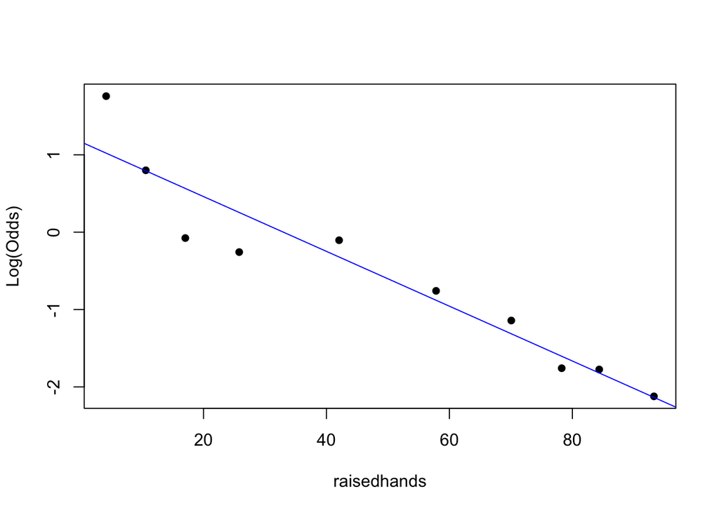

```r
emplogitplot1(StudentAbsenceDays~raisedhands, data=StudentPerformance, ngroups=10)
```

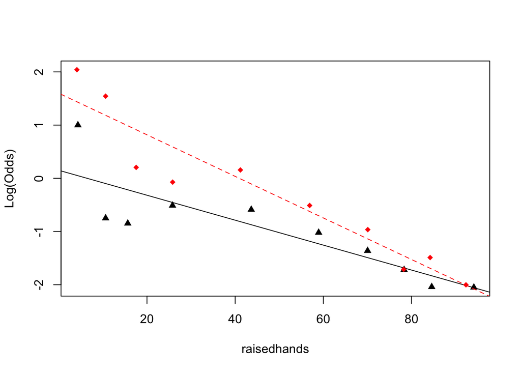

```r
emplogitplot2(StudentAbsenceDays~raisedhands+gender, ngroups=10, data=StudentPerformance)
```

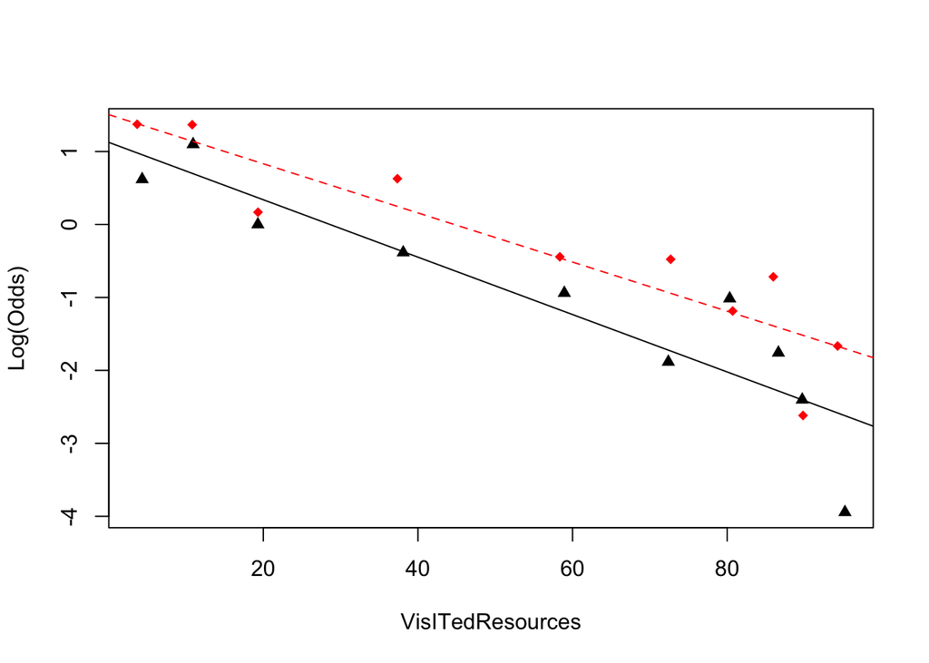

```r
emplogitplot2(StudentAbsenceDays~VisITedResources+gender, ngroups=10, data=StudentPerformance)
```

```r
StudentPerformance.2 = StudentPerformance.1
StudentPerformance.2$PS.gender.int = StudentPerformance.2$raisedhands*(as.numeric(StudentPerformance$gender)-1)

StudentPerformance.2 = as.data.frame(StudentPerformance.1)
```

```r
bestglm(StudentPerformance.2, family=binomial)
```

```
## Morgan-Tatar search since family is non-gaussian.
```

```
## BIC
## BICq equivalent for q in (0.330535927826353, 0.892947820534757)
## Best Model:
##                     Estimate  Std. Error   z value     Pr(>|z|)
## (Intercept)       1.13492118 0.277473437  4.090198 4.310059e-05
## genderM           0.64998998 0.237990171  2.731163 6.311122e-03
## raisedhands      -0.01937584 0.004817794 -4.021725 5.777339e-05
## VisITedResources -0.02171127 0.004347150 -4.994368 5.902876e-07
```

```r
StudentPerformance.2.bestglm = bestglm(StudentPerformance.2, family=binomial)
```

```
## Morgan-Tatar search since family is non-gaussian.
```

```r
StudentPerformance.2.bestglm$BestModels
```

| gender | raisedhands | VisITedResources | AnnouncementsView | Discussion | ParentschoolSatisfaction | Criterion |
| --- | --- | --- | --- | --- | --- | --- |
| TRUE | TRUE | TRUE | FALSE | FALSE | FALSE | 514.7144 |
| FALSE | TRUE | TRUE | FALSE | FALSE | FALSE | 516.1259 |
| TRUE | TRUE | TRUE | FALSE | TRUE | FALSE | 519.2447 |
| TRUE | TRUE | TRUE | TRUE | FALSE | FALSE | 519.6003 |
| FALSE | TRUE | TRUE | FALSE | TRUE | FALSE | 519.6621 |

### BEST MODEL

```r
bestMod = glm(StudentAbsenceDays~raisedhands+gender+VisITedResources, data=StudentPerformance, family=binomial)
summary(bestMod)
```

```
##
## Call:
## glm(formula = StudentAbsenceDays ~ raisedhands + gender + VisITedResources,
##     family = binomial, data = StudentPerformance)
##
## Deviance Residuals:
##     Min       1Q   Median       3Q      Max
## -1.9129  -0.7245  -0.4713   0.8044   2.2790
##
## Coefficients:
##                   Estimate Std. Error z value Pr(>|z|)
## (Intercept)       1.134921   0.277473   4.090 4.31e-05 ***
## raisedhands      -0.019376   0.004818  -4.022 5.78e-05 ***
## genderM           0.649990   0.237990   2.731  0.00631 **
## VisITedResources -0.021711   0.004347  -4.994 5.90e-07 ***
## ---
## Signif. codes:  0 '***' 0.001 '**' 0.01 '*' 0.05 '.' 0.1 ' ' 1
##
## (Dispersion parameter for binomial family taken to be 1)
##
##     Null deviance: 645.27  on 479  degrees of freedom
## Residual deviance: 496.19  on 476  degrees of freedom
## AIC: 504.19
##
## Number of Fisher Scoring iterations: 4
```